# Mouse Pregnancy Plasma Exosome Time Course

Sean Nguyen

# Experimental Design

Six animals will be use for six different time points throughout pregnancy

# Importing your data

This section will demonstrate how to get started with analyzing data using R.

**You will first want to tell R where to find all of your files, you can do this with the “setwd” command**  
- This is where R will read in all of your files and output your data that you generate(plots, CSVs, etc)

**Next we will want to import the csv into r and we can accomplish this with the “read_csv” function**  
- This will import our csv file and we can make this an object known as “data”  
- Anytime we want to see the dataframe we can simply run “data”

```r
setwd("~/Library/Mobile\ Documents/com~apple~CloudDocs/time-course/")
rawdata <- "MASTER-ExperimentSummary.csv"
timecourse <- "timecourse2017.csv"
data <- read_csv(rawdata)
tc <- read_csv(timecourse, na = c("","NA"))
```

We can quickly look at the dimensions of the dataframe with **dim()**

```r
dim(data)
```

```
[1] 1000  223
```

```r
dim(tc)
```

```
[1] 36 10
```

We can see the top of the dataframe with **head()**

```r
head(data)
```

| particle_size | 1_250_1_00 | 1_250_1_01 | 1_250_1_02 | 1_250_2_00 | 1_250_2_01 | 1_250_2_02 | 2_500_1_00 | 2_500_1_01 | 2_500_1_02 | 2_500_2_00 | 2_500_2_01 | 2_500_2_02 | 3_500_1_00 | 3_500_1_01 | 3_500_1_02 | 3_500_2_00 | 3_500_2_01 | 3_500_2_02 | 4_500_1_00 | 4_500_1_01 | 4_500_1_02 | 4_500_2_00 | 4_500_2_01 | 4_500_2_02 | 5_500_1_00 | 5_500_1_01 | 5_500_1_02 | 5_500_2_00 | 5_500_2_01 | … |
| --- | --- | --- | --- | --- | --- | --- | --- | --- | --- | --- | --- | --- | --- | --- | --- | --- | --- | --- | --- | --- | --- | --- | --- | --- | --- | --- | --- | --- | --- | --- |
| 0.5 | 0 | 0 | 0 | 0 | 0 | 0 | 0 | 0 | 0 | 0 | 0 | 0 | 0 | 0 | 0 | 0 | 0 | 0 | 0 | 0 | 0 | 0 | 0 | 0 | 0 | 0 | 0 | 0 | 0 | … |
| 1.5 | 0 | 0 | 0 | 0 | 0 | 0 | 0 | 0 | 0 | 0 | 0 | 0 | 0 | 0 | 0 | 0 | 0 | 0 | 0 | 0 | 0 | 0 | 0 | 0 | 0 | 0 | 0 | 0 | 0 | … |
| 2.5 | 0 | 0 | 0 | 0 | 0 | 0 | 0 | 0 | 0 | 0 | 0 | 0 | 0 | 0 | 0 | 0 | 0 | 0 | 0 | 0 | 0 | 0 | 0 | 0 | 0 | 0 | 0 | 0 | 0 | … |
| 3.5 | 0 | 0 | 0 | 0 | 0 | 0 | 0 | 0 | 0 | 0 | 0 | 0 | 0 | 0 | 0 | 0 | 0 | 0 | 0 | 0 | 0 | 0 | 0 | 0 | 0 | 0 | 0 | 0 | 0 | … |
| 4.5 | 0 | 0 | 0 | 0 | 0 | 0 | 0 | 0 | 0 | 0 | 0 | 0 | 0 | 0 | 0 | 0 | 0 | 0 | 0 | 0 | 0 | 0 | 0 | 0 | 0 | 0 | 0 | 0 | 0 | … |
| 5.5 | 0 | 0 | 0 | 0 | 0 | 0 | 0 | 0 | 0 | 0 | 0 | 0 | 0 | 0 | 0 | 0 | 0 | 0 | 0 | 0 | 0 | 0 | 0 | 0 | 0 | 0 | 0 | 0 | 0 | … |

You can also look at the bottom with **tail()**

```r
tail(data)
```

| particle_size | 1_250_1_00 | 1_250_1_01 | 1_250_1_02 | 1_250_2_00 | 1_250_2_01 | 1_250_2_02 | 2_500_1_00 | 2_500_1_01 | 2_500_1_02 | 2_500_2_00 | 2_500_2_01 | 2_500_2_02 | 3_500_1_00 | 3_500_1_01 | 3_500_1_02 | 3_500_2_00 | 3_500_2_01 | 3_500_2_02 | 4_500_1_00 | 4_500_1_01 | 4_500_1_02 | 4_500_2_00 | 4_500_2_01 | 4_500_2_02 | 5_500_1_00 | 5_500_1_01 | 5_500_1_02 | 5_500_2_00 | 5_500_2_01 | … |
| --- | --- | --- | --- | --- | --- | --- | --- | --- | --- | --- | --- | --- | --- | --- | --- | --- | --- | --- | --- | --- | --- | --- | --- | --- | --- | --- | --- | --- | --- | --- |
| 994.5 | 0 | 0 | 0 | 0 | 0 | 0 | 0 | 0 | 0 | 0 | 0 | 0 | 0 | 0 | 0 | 0 | 0 | 0 | 0 | 0 | 0 | 0 | 0 | 0 | 0 | 0 | 0 | 0 | 0 | … |
| 995.5 | 0 | 0 | 0 | 0 | 0 | 0 | 0 | 0 | 0 | 0 | 0 | 0 | 0 | 0 | 0 | 0 | 0 | 0 | 0 | 0 | 0 | 0 | 0 | 0 | 0 | 0 | 0 | 0 | 0 | … |
| 996.5 | 0 | 0 | 0 | 0 | 0 | 0 | 0 | 0 | 0 | 0 | 0 | 0 | 0 | 0 | 0 | 0 | 0 | 0 | 0 | 0 | 0 | 0 | 0 | 0 | 0 | 0 | 0 | 0 | 0 | … |
| 997.5 | 0 | 0 | 0 | 0 | 0 | 0 | 0 | 0 | 0 | 0 | 0 | 0 | 0 | 0 | 0 | 0 | 0 | 0 | 0 | 0 | 0 | 0 | 0 | 0 | 0 | 0 | 0 | 0 | 0 | … |
| 998.5 | 0 | 0 | 0 | 0 | 0 | 0 | 0 | 0 | 0 | 0 | 0 | 0 | 0 | 0 | 0 | 0 | 0 | 0 | 0 | 0 | 0 | 0 | 0 | 0 | 0 | 0 | 0 | 0 | 0 | … |
| 999.5 | 0 | 0 | 0 | 0 | 0 | 0 | 0 | 0 | 0 | 0 | 0 | 0 | 0 | 0 | 0 | 0 | 0 | 0 | 0 | 0 | 0 | 0 | 0 | 0 | 0 | 0 | 0 | 0 | 0 | … |

# Convert data from wide type to long

```r
data1 <- data %>%
  gather(Sample,Count,2:223)
data1
```

| particle_size | Sample | Count |
| --- | --- | --- |
| 0.5 | 1_250_1_00 | 0 |
| 1.5 | 1_250_1_00 | 0 |
| 2.5 | 1_250_1_00 | 0 |
| 3.5 | 1_250_1_00 | 0 |
| 4.5 | 1_250_1_00 | 0 |
| 5.5 | 1_250_1_00 | 0 |
| 6.5 | 1_250_1_00 | 0 |
| 7.5 | 1_250_1_00 | 0 |
| 8.5 | 1_250_1_00 | 0 |
| 9.5 | 1_250_1_00 | 0 |

[output cut: 990 more lines]

# Separate samples by identifiers

[output not shown]

[output cut: 990 more lines]

# Data types

R works with a variety of different data structures including, strings, vectors, factors, lists, integers, numerics and characters.  
What I found that works for me is to think of factors and categorical variables.

We can inspect the structure of the data type

```r
str(data2)
```

```
Classes ‘tbl_df’, ‘tbl’ and 'data.frame':   222000 obs. of  6 variables:
 $ particle_size  : num  0.5 1.5 2.5 3.5 4.5 5.5 6.5 7.5 8.5 9.5 ...
 $ Sample_ID      : chr  "1" "1" "1" "1" ...
 $ Dilution_factor: chr  "250" "250" "250" "250" ...
 $ Injection      : chr  "1" "1" "1" "1" ...
 $ Tech_rep       : chr  "00" "00" "00" "00" ...
 $ Count          : int  0 0 0 0 0 0 0 0 0 0 ...
```

# Fixing data types

We can fix the data types to make things a factor (typically categorical variables) or numeric for numbers The typical way to reformat data types is to call the data and specify the column name using **dataframe_name$column_name**  
Next you need to assign the column name **as.factor()** or **as.numeric()**, be sure to make sure the column is specified  
Then you will want to make **as.factor()** or **as.numeric()** equal to the column that you are changing

```r
data2$Sample_ID <- as.factor(data2$Sample_ID)
data2$Dilution_factor <- as.numeric(data2$Dilution_factor)
data2$Injection<- as.factor(data2$Injection)
data2$Tech_rep <- as.numeric(data2$Tech_rep)
```

Afterwards, be sure to check the data structure to make sure you did things correctly using the **str()**

```r
str(data2)
```

```
Classes ‘tbl_df’, ‘tbl’ and 'data.frame':   222000 obs. of  6 variables:
 $ particle_size  : num  0.5 1.5 2.5 3.5 4.5 5.5 6.5 7.5 8.5 9.5 ...
 $ Sample_ID      : Factor w/ 36 levels "1","10","11",..: 1 1 1 1 1 1 1 1 1 1 ...
 $ Dilution_factor: num  250 250 250 250 250 250 250 250 250 250 ...
 $ Injection      : Factor w/ 2 levels "1","2": 1 1 1 1 1 1 1 1 1 1 ...
 $ Tech_rep       : num  0 0 0 0 0 0 0 0 0 0 ...
 $ Count          : int  0 0 0 0 0 0 0 0 0 0 ...
```

# Back-Calculate

```r
data2 <- data2 %>%
   mutate(True_Count=Dilution_factor*Count)
```

We can use **group_by()** to effectively ‘lock’ in certain variables/factors within a particular column. In our case we will use group_by to ‘lock’ the particle_size, dilution factor and injection columns.  
**mutate()**is a command that will create a new column, the name of the column comes first and then whatever you want the column to be comes afterwards. Example code `data %>% mutate(new_column_name=column1*column2)`  
Next we can use **summarise()** to calculate the number of rows within a certain group, calculate the average, standard deviation and standard error of the mean.

```r
data3 <- data2 %>%
  group_by(particle_size,Sample_ID,Dilution_factor,Injection) %>%
  summarise( tech_N = length(True_Count),
             tech_mean = mean(True_Count),
             tech_sd = sd(True_Count),
             tech_se = tech_sd/sqrt(tech_N))
data3
```

| particle_size | Sample_ID | Dilution_factor | Injection | tech_N | tech_mean | tech_sd | tech_se |
| --- | --- | --- | --- | --- | --- | --- | --- |
| 0.5 | 1 | 250 | 1 | 3 | 0.000 | 0.000 | 0.000 |
| 0.5 | 1 | 250 | 2 | 3 | 0.000 | 0.000 | 0.000 |
| 0.5 | 10 | 500 | 1 | 3 | 0.000 | 0.000 | 0.000 |
| 0.5 | 10 | 500 | 2 | 3 | 0.000 | 0.000 | 0.000 |
| 0.5 | 11 | 500 | 1 | 3 | 0.000 | 0.000 | 0.000 |
| 0.5 | 11 | 500 | 2 | 3 | 0.000 | 0.000 | 0.000 |
| 0.5 | 12 | 500 | 1 | 3 | 0.000 | 0.000 | 0.000 |
| 0.5 | 12 | 500 | 2 | 3 | 0.000 | 0.000 | 0.000 |
| 0.5 | 13 | 500 | 1 | 3 | 0.000 | 0.000 | 0.000 |
| 0.5 | 13 | 500 | 2 | 3 | 0.000 | 0.000 | 0.000 |

[output cut: 990 more lines]

# Refactoring to get the sample ID in the correct order

```r
str(tc)
```

```
Classes ‘tbl_df’, ‘tbl’ and 'data.frame':   36 obs. of  10 variables:
 $ Day       : int  1 1 1 1 1 1 5 5 5 5 ...
 $ Sample_ID : int  1 2 3 4 5 6 7 8 9 10 ...
 $ Weight    : num  19.6 18.6 19.3 20.5 18.7 ...
 $ Pups      : int  0 0 0 0 0 0 10 10 9 6 ...
 $ Pup_left  : int  0 0 0 0 0 0 4 5 4 6 ...
 $ Pup_right : int  0 0 0 0 0 0 6 5 5 0 ...
 $ placenta1 : num  NA NA NA NA NA NA NA NA NA NA ...
 $ placenta_2: num  NA NA NA NA NA NA NA NA NA NA ...
 $ placenta_3: num  NA NA NA NA NA NA NA NA NA NA ...
 $ Resorp    : int  NA NA NA NA NA NA NA NA 0 NA ...
 - attr(*, "spec")=List of 2
  ..$ cols   :List of 10
  .. ..$ Day       : list()
  .. .. ..- attr(*, "class")= chr  "collector_integer" "collector"
  .. ..$ Sample_ID : list()
  .. .. ..- attr(*, "class")= chr  "collector_integer" "collector"
  .. ..$ Weight    : list()
  .. .. ..- attr(*, "class")= chr  "collector_double" "collector"
  .. ..$ Pups      : list()
  .. .. ..- attr(*, "class")= chr  "collector_integer" "collector"
  .. ..$ Pup_left  : list()
  .. .. ..- attr(*, "class")= chr  "collector_integer" "collector"
  .. ..$ Pup_right : list()
  .. .. ..- attr(*, "class")= chr  "collector_integer" "collector"
  .. ..$ placenta1 : list()
  .. .. ..- attr(*, "class")= chr  "collector_double" "collector"
  .. ..$ placenta_2: list()
  .. .. ..- attr(*, "class")= chr  "collector_double" "collector"
  .. ..$ placenta_3: list()
  .. .. ..- attr(*, "class")= chr  "collector_double" "collector"
  .. ..$ Resorp    : list()
  .. .. ..- attr(*, "class")= chr  "collector_integer" "collector"
  ..$ default: list()
  .. ..- attr(*, "class")= chr  "collector_guess" "collector"
  ..- attr(*, "class")= chr "col_spec"
```

```r
tc$Sample_ID <- as.factor(tc$Sample_ID)
tc$Day <- as.factor(tc$Day)
tc$Weight <- as.numeric(tc$Weight)
tc1 <- tc %>%
  select(Day:Pups)
str(tc1)
```

```
Classes ‘tbl_df’, ‘tbl’ and 'data.frame':   36 obs. of  4 variables:
 $ Day      : Factor w/ 6 levels "1","5","10","14",..: 1 1 1 1 1 1 2 2 2 2 ...
 $ Sample_ID: Factor w/ 36 levels "1","2","3","4",..: 1 2 3 4 5 6 7 8 9 10 ...
 $ Weight   : num  19.6 18.6 19.3 20.5 18.7 ...
 $ Pups     : int  0 0 0 0 0 0 10 10 9 6 ...
 - attr(*, "spec")=List of 2
  ..$ cols   :List of 10
  .. ..$ Day       : list()
  .. .. ..- attr(*, "class")= chr  "collector_integer" "collector"
  .. ..$ Sample_ID : list()
  .. .. ..- attr(*, "class")= chr  "collector_integer" "collector"
  .. ..$ Weight    : list()
  .. .. ..- attr(*, "class")= chr  "collector_double" "collector"
  .. ..$ Pups      : list()
  .. .. ..- attr(*, "class")= chr  "collector_integer" "collector"
  .. ..$ Pup_left  : list()
  .. .. ..- attr(*, "class")= chr  "collector_integer" "collector"
  .. ..$ Pup_right : list()
  .. .. ..- attr(*, "class")= chr  "collector_integer" "collector"
  .. ..$ placenta1 : list()
  .. .. ..- attr(*, "class")= chr  "collector_double" "collector"
  .. ..$ placenta_2: list()
  .. .. ..- attr(*, "class")= chr  "collector_double" "collector"
  .. ..$ placenta_3: list()
  .. .. ..- attr(*, "class")= chr  "collector_double" "collector"
  .. ..$ Resorp    : list()
  .. .. ..- attr(*, "class")= chr  "collector_integer" "collector"
  ..$ default: list()
  .. ..- attr(*, "class")= chr  "collector_guess" "collector"
  ..- attr(*, "class")= chr "col_spec"
```

```r
test1 <- inner_join(tc1,data3, by= "Sample_ID")
```

```
joining factors with different levels, coercing to character vector
```

# Summarize samples by injection

```r
data4 <- data3 %>%
  group_by(particle_size,Sample_ID,Dilution_factor) %>%
  summarise( inj_N = length(tech_mean),
             inj_mean = mean(tech_mean),
             inj_sd = sd(tech_mean),
             inj_se = inj_sd/sqrt(inj_N))
data4
```

| particle_size | Sample_ID | Dilution_factor | inj_N | inj_mean | inj_sd | inj_se |
| --- | --- | --- | --- | --- | --- | --- |
| 0.5 | 1 | 250 | 2 | 0.000000e+00 | 0.000000e+00 | 0.000000e+00 |
| 0.5 | 10 | 500 | 2 | 0.000000e+00 | 0.000000e+00 | 0.000000e+00 |
| 0.5 | 11 | 500 | 2 | 0.000000e+00 | 0.000000e+00 | 0.000000e+00 |
| 0.5 | 12 | 500 | 2 | 0.000000e+00 | 0.000000e+00 | 0.000000e+00 |
| 0.5 | 13 | 500 | 2 | 0.000000e+00 | 0.000000e+00 | 0.000000e+00 |
| 0.5 | 14 | 500 | 2 | 0.000000e+00 | 0.000000e+00 | 0.000000e+00 |
| 0.5 | 15 | 500 | 2 | 0.000000e+00 | 0.000000e+00 | 0.000000e+00 |
| 0.5 | 16 | 500 | 2 | 0.000000e+00 | 0.000000e+00 | 0.000000e+00 |
| 0.5 | 17 | 500 | 2 | 0.000000e+00 | 0.000000e+00 | 0.000000e+00 |
| 0.5 | 18 | 500 | 2 | 0.000000e+00 | 0.000000e+00 | 0.000000e+00 |

[output cut: 990 more lines]

```r
test2 <- left_join(tc1,data4, by= "Sample_ID")
```

```
joining factors with different levels, coercing to character vector
```

# Graphing data

Now that the data is structured properly we can graph the data to get an idea of what is going on.  
We will use the **ggplot()**

[figure not shown]

```r
graph1 <- test1 %>%
  ggplot(aes(x=particle_size, y=tech_mean,color=Injection ))+ #plot
  geom_ribbon(aes(ymin=tech_mean-tech_se, ymax=tech_mean+tech_se),alpha=0.2,fill = alpha('grey12', 0.2)) + #error bars
  geom_line(size=2.0) + xlim(0,500)+ #line size, x-axis scale
  scale_y_continuous(expand=c(0,0))+ #set bottom of graph
  xlab("Particle Size") + # X axis label
  ylab("\nMean Particle Concentration/ml\n") + # Y axis label
  ggtitle("Nanosight Histogram of\nVirgin Mouse Plasma")+ #title
  labs(color="Injection")+ #Label table title
  facet_grid(. ~ Sample_ID)
graph1
```

Next we can graph **data4**

[figure not shown]

```r
graph2 <- data4 %>%
  ggplot(aes(x=particle_size, y=inj_mean,color=Sample_ID ))+ #plot
  geom_ribbon(aes(ymin=inj_mean-inj_se, ymax=inj_mean+inj_se),alpha=0.2,fill = alpha('grey12', 0.2)) + #error bars
  geom_line(size=2) + xlim(0,500)+ #line size, x-axis scale
  scale_y_continuous(expand=c(0,0))+ #set bottom of graph
  xlab("Particle Size") + # X axis label
  ylab("\nMean Particle Concentration/ml\n") + # Y axis label
  ggtitle("Nanosight Histogram of\nVirgin Mouse Plasma")+ #title
  labs(color="Condition")+ #Label table title
  facet_grid(. ~ Sample_ID)
graph2
```

```r
plot_grid(graph1,graph2, labels = c("Individual\nInjections","Averaged"),nrow = 2, align = "v")
```

[output not shown]

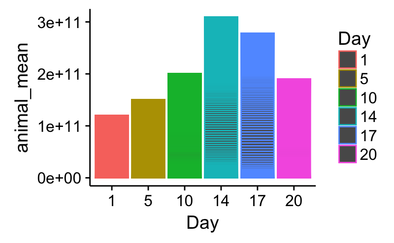

```r
test3 <- test2 %>%
  group_by(Day,particle_size) %>%
  summarise(animal_N=length(Sample_ID),
            animal_mean = mean(inj_mean),
             animal_sd = sd(inj_mean),
             animal_se = animal_sd/sqrt(animal_N))
test3 %>%
  ggplot(aes(x=Day, y=animal_mean,color=Day))+
  geom_col()
```

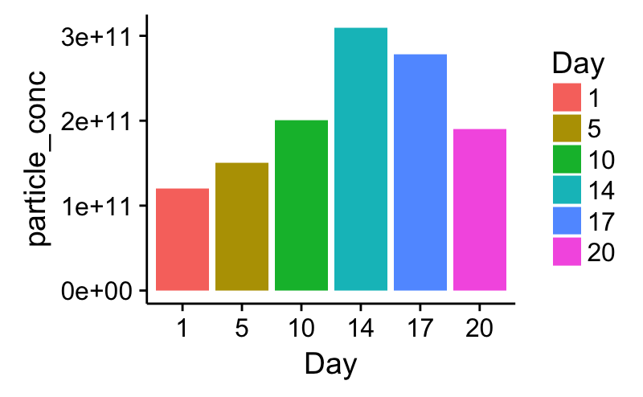

```r
test4 <- test3 %>%
  group_by(Day) %>%
  summarise(particle_conc=sum(animal_mean))
test4 %>%
  ggplot(aes(x=Day, y=particle_conc,fill=Day))+
  geom_bar(stat="identity")
```

[output not shown]

[output cut: 25 more lines]

```r
TukeyHSD(fit)
```

```
  Tukey multiple comparisons of means
    95% family-wise confidence level

Fit: aov(formula = particle_conc ~ Day, data = test5)

$Day
               diff           lwr          upr     p adj
5-1     35425375625 -202610707305 273461458555 0.9973318
10-1    60118357092 -189535992869 309772707053 0.9759452
14-1   169793149531  -68242933400 407829232461 0.2798381
17-1   138413120272  -99622962658 376449203202 0.4979387
20-1    50448712722 -187587370208 288484795652 0.9863133
10-5    24692981467 -224961368494 274347331428 0.9996277
14-5   134367773906 -103668309025 372403856836 0.5297813
17-5   102987744647 -135048338283 341023827577 0.7723750
20-5    15023337097 -223012745833 253059420027 0.9999592
14-10  109674792439 -139979557522 359329142400 0.7612249
17-10   78294763181 -171359586780 327949113141 0.9279384
20-10   -9669644369 -259323994330 239984705591 0.9999964
17-14  -31380029258 -269416112188 206656053672 0.9985032
20-14 -119344436808 -357380519738 118691646122 0.6495118
20-17  -87964407550 -326000490480 150071675380 0.8663352
```